# BCB420 Assignment 2 - Nayeon Hyun

2024-03-10

## Introduction

For my dataset, I chose the paper, [Human germline biallelic complete NFAT1 deficiency causes the triad of joint contractures, osteochondromas, and susceptibility to B cell malignancy](https://www.ncbi.nlm.nih.gov/geo/query/acc.cgi?acc=GSE193414). This dataset was downloaded from GEO and its accession ID is GSE193414. Sharma et al. (2022)

There are 18 bulk RNA-seq samples from three patients. One patient is the first reported case of human complete NFAT1 deficiency. The other two are his parents who had a consanguineous relationship. Half of the 18 samples (labelled as “patient”) are infected with an empty vector, thus is the negative control. The other 9 samples are infected with WT-NFATC2 which is the test condition. Sharma et al. (2022)

Each replicate’s patient and rescue samples were treated with PMAIonomycin and IL-1b. Thus there are 3 treatment groups, one untreated, PMAIono, and IL1b for each replicate’s patient and rescue samples. Sharma et al. (2022)

To start the differential expression analysis, we will get the normalized count matrix and processed metadata from Assignment 1.

```r
## load normalised expression data from A1
path <- file.path(getwd(), "GSE193414_normalizedCounts.rds")
normalizedCM <- readRDS(path)

## load processed metadata from A1
path <- file.path(getwd(), "GSE193414_processedMetadata.rds")
metadata <- readRDS(path)
```

## Differential Gene Expression

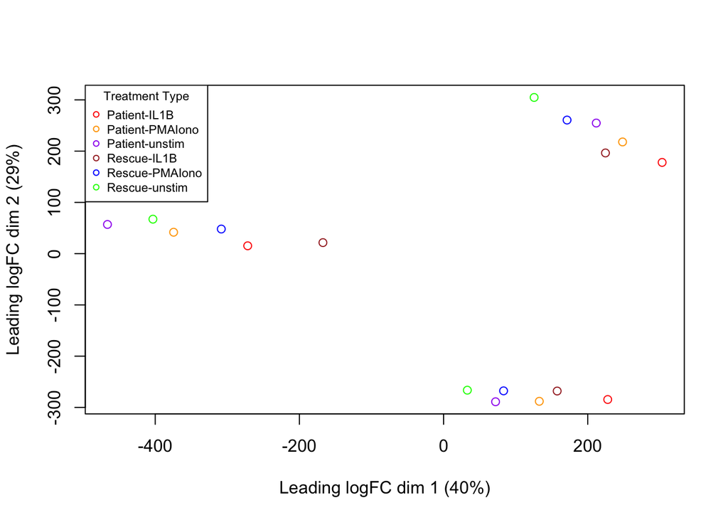

**Figure 1:** MDS plot of normalised counts where its colored by the 6 treatment types.

```r
# Plot by treatment group
limma::plotMDS(normalizedCM, labels=NULL,pch=1,
               col = c("red","orange","purple","brown", "blue", "green")[factor(metadata$Treatment_group)])
par(cex = 0.7) # change legend font size
legend("topleft", legend = levels(factor(metadata$Treatment_group)),
       col = c("red","orange","purple","brown", "blue", "green"), pch = 1, title = "Treatment Type", )
```

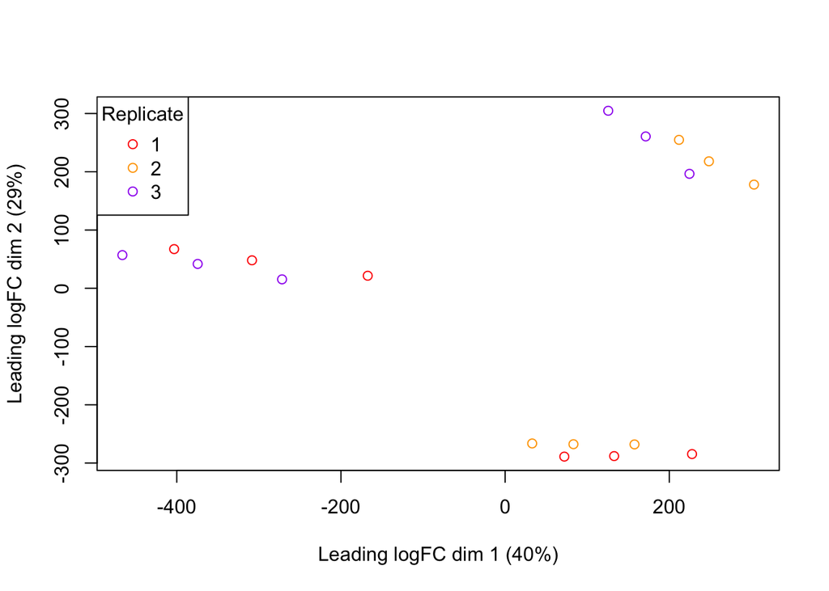

**Figure 2:** MDS plot of normalised counts where its colored by the 3 replicates.

```r
# Plot by replicate
limma::plotMDS(normalizedCM, labels=NULL,pch=1,
               col = c("red","orange","purple")[factor(metadata$Replicate)])
par(cex = 1) # change legend font size
legend("topleft", legend = levels(factor(metadata$Replicate)),
       col = c("red","orange","purple"), pch = 1, title = "Replicate", )
```

I will alter the metadata to add a column for this. I will also edit the `Treatment_group` column to exclude its sample type. For example, “Patient-unstim” and “Rescue-unstim” samples will have a treatment group as “unstim”.

```r
sampleType <- c()
treatmentGroup <- c()
for (group in metadata$Treatment_group) {
  splitDashes <- unlist(strsplit(group, "-", perl=TRUE))
  sampleType <- c(sampleType, splitDashes[1])
  treatmentGroup <- c(treatmentGroup, splitDashes[2])
}
metadata$Sample_type = sampleType
metadata$Treatment_group = treatmentGroup
head(metadata)
```

```
##                         title Replicate Treatment_group CountMatrix_colname
## GSM5799904   N2-Rescue-unstim         2          unstim         Res2_unstim
## GSM5799905     N2-Rescue-IL1B         2            IL1B           Res2_IL1B
## GSM5799906  N2-Rescue-PMAIono         2         PMAIono        Res2_PMAIono
## GSM5799907  N3-Patient-unstim         3          unstim           P3_unstim
## GSM5799908    N3-Patient-IL1B         3            IL1B             P3_IL1B
## GSM5799909 N3-Patient-PMAIono         3         PMAIono          P3_PMAIono
##            Sample_type
## GSM5799904      Rescue
## GSM5799905      Rescue
## GSM5799906      Rescue
## GSM5799907     Patient
## GSM5799908     Patient
## GSM5799909     Patient
```

We will now look at the MDS plots for the new columns. Ritchie et al. (2015)

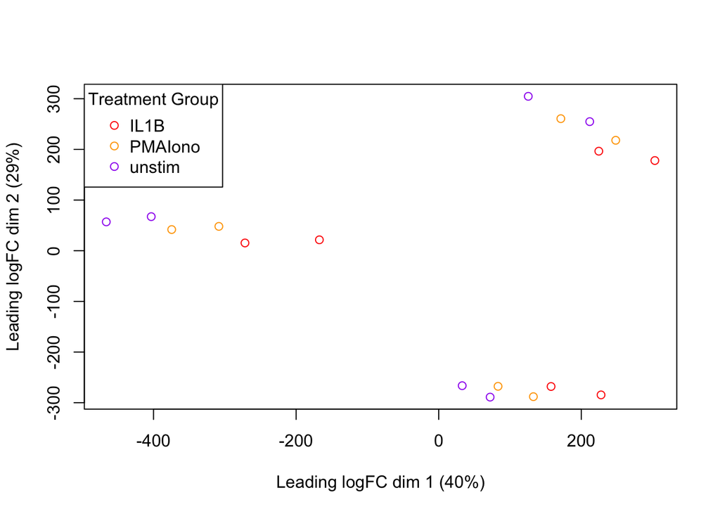

**Figure 3:** MDS plot of normalised counts where its colored by the newly simplified 3 treatment groups

```r
# Plot by new treatment group
limma::plotMDS(normalizedCM, labels=NULL,pch=1,
               col = c("red","orange","purple")[factor(metadata$Treatment_group)])
par(cex = 1) # change legend font size
legend("topleft", legend = levels(factor(metadata$Treatment_group)),
       col = c("red","orange","purple"), pch = 1, title = "Treatment Group", )
```

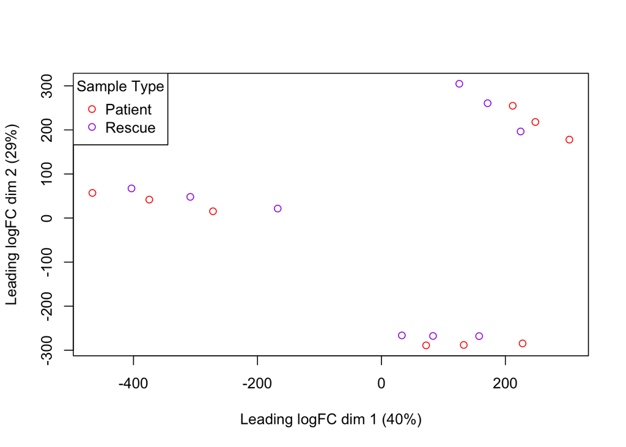

**Figure 4:** MDS plot of normalised counts where its colored by the 2 sample types.

```r
# Plot by sample type
limma::plotMDS(normalizedCM, labels=NULL,pch=1,
               col = c("red","purple")[factor(metadata$Sample_type)])
par(cex = 1) # change legend font size
legend("topleft", legend = levels(factor(metadata$Sample_type)),
       col = c("red","purple"), pch = 1, title = "Sample Type", )
```

There are three treatments groups, so I will first create two different counts matrices, for unstim vs IL1B, and unstim vs PMAIono.

```r
unstimVsIL1B <- metadata[metadata$Treatment_group == "unstim" | metadata$Treatment_group == "IL1B",]
normalizedCM_IL1B <- normalizedCM[,unstimVsIL1B$CountMatrix_colname]

unstimVsPMAIono <- metadata[metadata$Treatment_group == "unstim" | metadata$Treatment_group == "PMAIono",]
normalizedCM_PMAIono<- normalizedCM[,unstimVsPMAIono$CountMatrix_colname]
```

### Designing Model

The model would use both the sample type and the treatment type. We will use the `edgeR` package for our modelling. Robinson, McCarthy, and Smyth (2010)

```r
modelIL1B <- model.matrix(~ unstimVsIL1B$Sample_type + unstimVsIL1B$Treatment_group)
modelPMAIono <- model.matrix(~ unstimVsPMAIono$Sample_type + unstimVsPMAIono$Treatment_group)
```

### Fitting Counts into Model

We now fit the counts into the model. Robinson, McCarthy, and Smyth (2010)

```r
dgeListIL1B = DGEList(counts=normalizedCM_IL1B, group=unstimVsIL1B$Treatment_group)
dgeListIL1B <- estimateDisp(dgeListIL1B, modelIL1B)
IL1BFit <- glmQLFit(dgeListIL1B, modelIL1B)

dgeListPMAIono = DGEList(counts=normalizedCM_PMAIono, group=unstimVsPMAIono$Treatment_group)
dgeListPMAIono <- estimateDisp(dgeListPMAIono, modelPMAIono)
PMAIonoFit <- glmQLFit(dgeListPMAIono, modelPMAIono)
```

The Quasilikelihood model is used to calculate the differential expression. Robinson, McCarthy, and Smyth (2010)

```r
qlfIL1B <- glmQLFTest(IL1BFit, coef="unstimVsIL1B$Treatment_groupunstim")
knitr::kable(topTags(qlfIL1B),type='html',row.names=TRUE)
```

|  | logFC | logCPM | F | PValue | FDR |
| --- | --- | --- | --- | --- | --- |
| CXCL1 | -5.443920 | 10.785890 | 6905.687 | 0 | 0 |
| CSF3 | -9.897775 | 6.351461 | 5822.403 | 0 | 0 |
| CXCL2 | -5.005726 | 8.679384 | 5269.156 | 0 | 0 |
| NFKBIZ | -5.126234 | 7.828744 | 4442.730 | 0 | 0 |
| CXCL3 | -5.318460 | 9.278391 | 3957.948 | 0 | 0 |
| NFKBIA | -2.336025 | 8.572261 | 3038.014 | 0 | 0 |
| IL1B | -6.578202 | 6.911698 | 3022.717 | 0 | 0 |
| ID1 | 3.154820 | 4.963186 | 2579.931 | 0 | 0 |
| IER3 | -2.687252 | 9.439626 | 2447.875 | 0 | 0 |
| TIAM2 | -3.452548 | 6.785026 | 2075.229 | 0 | 0 |

|  | x |
| --- | --- |
| 1 | BH |

|  | x |
| --- | --- |
| 1 | unstimVsIL1B$Treatment_groupunstim |

|  | x |
| --- | --- |
| 1 | glm |

```r
qlfPMAIono <- glmQLFTest(PMAIonoFit, coef="unstimVsPMAIono$Treatment_groupunstim")
knitr::kable(topTags(qlfPMAIono),type='html',row.names=TRUE)
```

|  | logFC | logCPM | F | PValue | FDR |
| --- | --- | --- | --- | --- | --- |
| HERPUD1 | -3.485813 | 8.047456 | 3733.266 | 0 | 0 |
| RCAN1 | -4.595967 | 9.375250 | 2137.170 | 0 | 0 |
| EIF2AK3 | -2.234271 | 6.057534 | 1948.028 | 0 | 0 |
| DUSP5 | -2.285729 | 7.851967 | 1811.371 | 0 | 0 |
| RGS16 | -4.615832 | 7.606531 | 1621.959 | 0 | 0 |
| GEM | -3.251957 | 8.588058 | 1517.711 | 0 | 0 |
| MMP1 | -4.116434 | 9.693579 | 1362.792 | 0 | 0 |
| TIAM2 | -3.027462 | 6.394566 | 1312.773 | 0 | 0 |
| PNRC1 | -2.191873 | 6.245901 | 1219.598 | 0 | 0 |
| DDIT3 | -3.791950 | 6.125683 | 1166.935 | 0 | 0 |

|  | x |
| --- | --- |
| 1 | BH |

|  | x |
| --- | --- |
| 1 | unstimVsPMAIono$Treatment_groupunstim |

|  | x |
| --- | --- |
| 1 | glm |

### Multiple hypothesis testing

We will now look for the number of genes that pass the threshold of p-value < 0.05, we can find the number of genes that pass the threshold. Robinson, McCarthy, and Smyth (2010)

```r
qlfIL1BHits <- topTags(qlfIL1B, sort.by = "PValue", n = nrow(normalizedCM_IL1B))
dim(qlfIL1BHits$table)
```

```
## [1] 12925     5
```

```r
length(which(qlfIL1BHits$table$PValue < 0.05))
```

```
## [1] 4362
```

```r
length(which(qlfIL1BHits$table$FDR < 0.05))
```

```
## [1] 2872
```

```r
FDR<-p.adjust(qlfIL1BHits$table$PValue,method="BH")
sum(FDR<0.05)
```

```
## [1] 2872
```

```r
qlfPMAIonoHits <- topTags(qlfPMAIono, sort.by = "PValue", n = nrow(normalizedCM_PMAIono))
dim(qlfPMAIonoHits$table)
```

```
## [1] 12925     5
```

```r
length(which(qlfPMAIonoHits$table$PValue < 0.05))
```

```
## [1] 4953
```

```r
length(which(qlfPMAIonoHits$table$FDR < 0.05))
```

```
## [1] 3782
```

```r
FDR<-p.adjust(qlfPMAIonoHits$table$PValue,method="BH")
sum(FDR<0.05)
```

```
## [1] 3782
```

There are 12925 total genes in both hits, but 4362 of the IL1B hits pass the threshold while 4953 of the PMAIono hits pass the p-value threshold. 2872 of the IL1B hits and 3782 of the PMAIono hits pass the correction.

### MA Plot

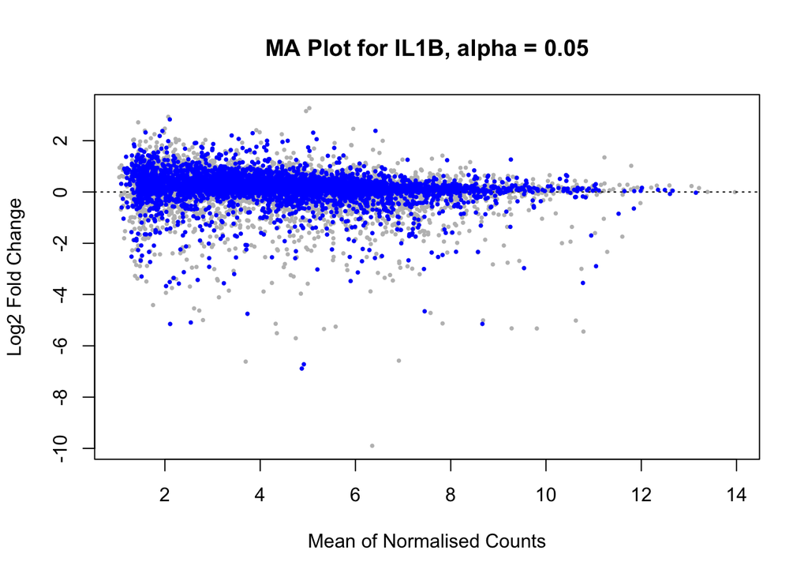

```
## integer(0)
```

```r
plot(qlfIL1B$table$logCPM, qlfIL1B$table$logFC, pch = 16, col = "grey", cex = 0.5,
     xlab = "Mean of Normalised Counts", ylab = "Log2 Fold Change",
     main = "MA Plot for IL1B, alpha = 0.05") +
     abline(h = 0, col = "black", lty = 3) +
    points(qlfIL1B$table$logCPM[ qlfIL1BHits$table$PValue < 0.05],
       qlfIL1B$table$logFC[qlfIL1BHits$table$PValue < 0.05],
       pch = 16, col = "blue", cex = 0.5)
```

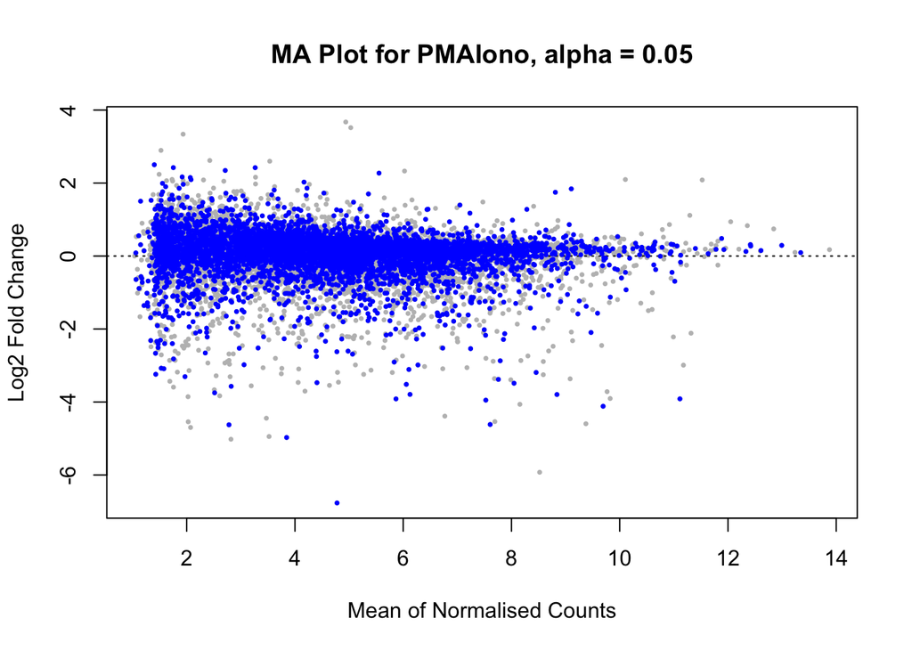

```
## integer(0)
```

```r
plot(qlfPMAIono$table$logCPM, qlfPMAIono$table$logFC, pch = 16, col = "grey", cex = 0.5,
     xlab = "Mean of Normalised Counts", ylab = "Log2 Fold Change",
     main = "MA Plot for PMAIono, alpha = 0.05") +
     abline(h = 0, col = "black", lty = 3) +
    points(qlfPMAIono$table$logCPM[ qlfPMAIonoHits$table$PValue < 0.05],
       qlfPMAIono$table$logFC[qlfPMAIonoHits$table$PValue < 0.05],
       pch = 16, col = "blue", cex = 0.5)
```

### Heatmaps

This annotated heatmap visualizes the top hits, which are the differentially expressed genes with a p-value < 0.05 for the IL1B vs unstim (control) data. The package `ComplexHeatmap` is used. Gu, Eils, and Schlesner (2016)

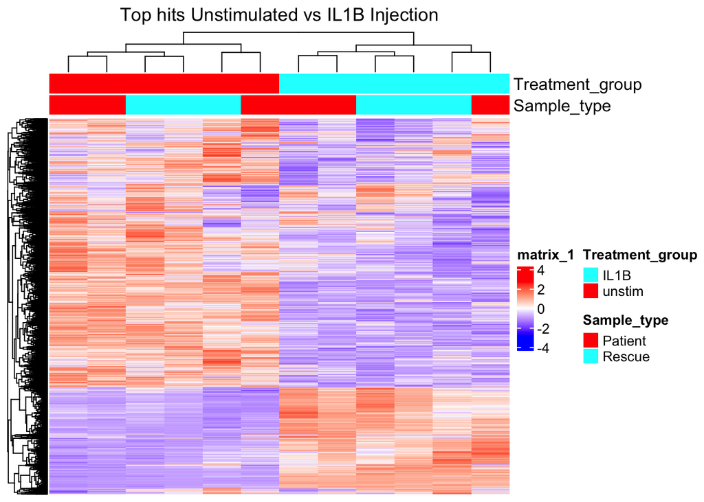

**Figure 7:** Heatmap of differentially expressed genes for IL1B injected vs control

```r
topHitsIL1B <-rownames(qlfIL1BHits$table)[qlfIL1BHits$table$PValue<0.05]
heatmapMatrixIL1B <- t(scale(t(normalizedCM_IL1B)))
heatmapMatrixTophitsIL1B <- t(scale(t(heatmapMatrixIL1B[which(rownames(heatmapMatrixIL1B) %in% topHitsIL1B),])))

if (min(heatmapMatrixTophitsIL1B) == 0) {
  heatmap_col = colorRamp2(c( 0, max(heatmapMatrixTophitsIL1B)), c( "white", "red"))
} else {
  heatmap_col = colorRamp2(c(min(heatmapMatrixTophitsIL1B), 0,
  max(heatmapMatrixTophitsIL1B)),
  c("blue", "white", "red"))
}

# creating unique labels
treatmentGroups <- c("unstim", "IL1B")
treatmentGroupsColors <- rainbow(n = length(treatmentGroups))
names(treatmentGroupsColors) <- treatmentGroups
sampleTypes <- c("Patient", "Rescue")
sampleTypesColors <- rainbow(n = length(sampleTypes))
names(sampleTypesColors) <- sampleTypes

# creating annotation labels
ha_pat <- HeatmapAnnotation(
  df = data.frame(Treatment_group = unstimVsIL1B$Treatment_group,
                   Sample_type = unstimVsIL1B$Sample_type ),
  col = list(Treatment_group = treatmentGroupsColors,
             Sample_type = sampleTypesColors),
  show_legend = TRUE)

#generation of heatmap
heatmapIL1B <- Heatmap(as.matrix(heatmapMatrixTophitsIL1B),
                       top_annotation = ha_pat,
                       cluster_rows = TRUE,
                       cluster_columns = TRUE,
                       show_row_dend = TRUE,
                       show_column_dend = TRUE,
                       col=heatmap_col,
                       show_column_names = FALSE,
                       show_row_names = FALSE,
                       show_heatmap_legend = TRUE,
                       column_title =("Top hits Unstimulated vs IL1B Injection"),
                       use_raster = FALSE
  )
heatmapIL1B
```

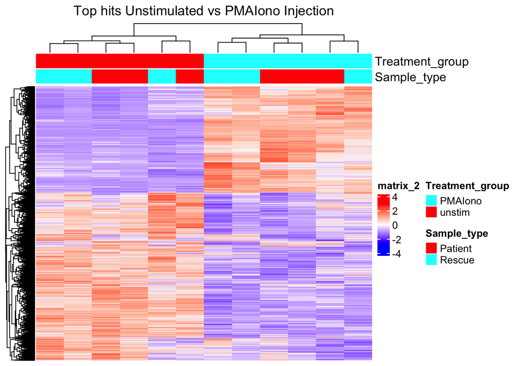

**Figure 7:** Heatmap of differentially expressed genes for PMAIono injected vs control

```r
topHitsPMAIono <-rownames(qlfPMAIonoHits$table)[qlfPMAIonoHits$table$PValue<0.05]
heatmapMatrixPMAIono <- t(scale(t(normalizedCM_PMAIono)))
heatmapMatrixTophitsPMAIono <- t(scale(t(heatmapMatrixPMAIono[which(rownames(heatmapMatrixPMAIono) %in% topHitsPMAIono),])))

if (min(heatmapMatrixTophitsPMAIono) == 0) {
  heatmap_col = colorRamp2(c( 0, max(heatmapMatrixTophitsPMAIono)), c( "white", "red"))
} else {
  heatmap_col = colorRamp2(c(min(heatmapMatrixTophitsPMAIono), 0,
  max(heatmapMatrixTophitsPMAIono)),
  c("blue", "white", "red"))
}

# creating unique labels
treatmentGroups <- c("unstim", "PMAIono")
treatmentGroupsColors <- rainbow(n = length(treatmentGroups))
names(treatmentGroupsColors) <- treatmentGroups
sampleTypes <- c("Patient", "Rescue")
sampleTypesColors <- rainbow(n = length(sampleTypes))
names(sampleTypesColors) <- sampleTypes

# creating annotation labels
ha_pat <- HeatmapAnnotation(
  df = data.frame(Treatment_group = unstimVsPMAIono$Treatment_group,
                   Sample_type = unstimVsPMAIono$Sample_type ),
  col = list(Treatment_group = treatmentGroupsColors,
             Sample_type = sampleTypesColors),
  show_legend = TRUE)

#generation of heatmap
heatmapPMAIono <- Heatmap(as.matrix(heatmapMatrixTophitsPMAIono),
                       top_annotation = ha_pat,
                       cluster_rows = TRUE,
                       cluster_columns = TRUE,
                       show_row_dend = TRUE,
                       show_column_dend = TRUE,
                       col=heatmap_col,
                       show_column_names = FALSE,
                       show_row_names = FALSE,
                       show_heatmap_legend = TRUE,
                       column_title =("Top hits Unstimulated vs PMAIono Injection"),
                       use_raster = FALSE
  )
heatmapPMAIono
```

We can see from the heatmaps that the Treatment groups clustering is more dependent which doesn’t really align with the MDS plot since we saw that the differing of sample types from the same replicate had significant differential expression.

## Thresholded over-representation analysis

I chose the thresholded list method because it was simpler to use.

These are the preliminary steps prior to running g:profiler.

```r
# find the genes that were over or underexpressed
IL1BUp <- qlfIL1B$table[qlfIL1B$table$PValue < 0.05 & qlfIL1B$table$logFC > 0, ] #upregulated genes
IL1BDown <- qlfIL1B$table[qlfIL1B$table$PValue < 0.05 & qlfIL1B$table$logFC < 0, ] #downregulated genes
PMAIonoUp <- qlfPMAIono$table[qlfPMAIono$table$PValue < 0.05 & qlfPMAIono$table$logFC > 0, ] #upregulated genes
PMAIonoDown <- qlfPMAIono$table[qlfPMAIono$table$PValue < 0.05 & qlfPMAIono$table$logFC < 0, ] #downregulated genes

# save these genes for pathway analysis in gprofiler directory.
if(!dir.exists("gprofiler")){
  dir.create("gprofiler")
}
write.table(x=rownames(qlfIL1B$table), file=file.path(getwd(),"gprofiler","IL1Bgenes.txt"), sep = "\t",row.names = FALSE, col.names = FALSE,quote = FALSE)
write.table(x=rownames(IL1BUp), file=file.path(getwd(),"gprofiler","IL1Bupreg.txt"), sep = "\t",row.names = FALSE, col.names = FALSE,quote = FALSE)
write.table(x=rownames(IL1BDown), file=file.path(getwd(),"gprofiler","IL1Bdown.txt"), sep = "\t",row.names = FALSE, col.names = FALSE,quote = FALSE)
write.table(x=rownames(qlfPMAIono$table), file=file.path(getwd(),"gprofiler","PMAIonogenes.txt"), sep = "\t",row.names = FALSE, col.names = FALSE,quote = FALSE)
write.table(x=rownames(PMAIonoUp), file=file.path(getwd(),"gprofiler","PMAIonoupreg.txt"), sep = "\t",row.names = FALSE, col.names = FALSE,quote = FALSE)
write.table(x=rownames(PMAIonoDown), file=file.path(getwd(),"gprofiler","PMAIonodown.txt"), sep = "\t",row.names = FALSE, col.names = FALSE,quote = FALSE)
```

Then, I initialize variables for g:profiler using the list of genes saved in the previous step. Kolberg et al. (2020)

```r
#where to put all the generated files
workingDir <- file.path(getwd(), "gprofiler")

# where to find the data files needed to run the analysis
dataDir <-  file.path(getwd(), "gprofiler")

# default max size of the genesets
maxGsSize <- 500

# default min size of the genesets
minGsSize <- 10

#min intersection between your genelist and the geneset
minInteraction <- 10

# organism parameter used for g:profiler.
organism <- "hsapiens"

# the below script will automatically download the latest gmt file from
# baderlab webstie.
destGMTFile = ""

getQuerySet <- function(genelistFile) {
  # takes in the file name containing the list of genes to be used for analysis
  #load in the file
  currentGenelist <- read.table(file = file.path(dataDir, genelistFile),
                               header = FALSE, sep = "\t", quote = "",
                               stringsAsFactors = FALSE)
  return (currentGenelist$V1)
}
```

Now we will run g:profiler for IL1B gene tables (all genes, upregulated and downregulated). Kolberg et al. (2020)

```r
# all genes in IL1B
gprofilerResultsIL1Bgenes <- gost(query = getQuerySet("IL1Bgenes.txt") ,
                          significant=FALSE,
                          ordered_query = FALSE,
                          exclude_iea=TRUE,
                          correction_method = "fdr",
                          organism = organism,
                          source = c("REAC","WP","GO:BP"))
# get the gprofiler results table
enrichmentResultsIL1B <- gprofilerResultsIL1Bgenes$result

dim(enrichmentResultsIL1B)
```

```
## [1] 15995    14
```

```r
# upregulated genes in IL1B
gprofilerResultsIL1BUp <- gost(query = getQuerySet("IL1Bupreg.txt") ,
                          significant=FALSE,
                          ordered_query = FALSE,
                          exclude_iea=TRUE,
                          correction_method = "fdr",
                          organism = organism,
                          source = c("REAC","WP","GO:BP"))
# get the gprofiler results table
enrichmentResultsIL1BUp <- gprofilerResultsIL1BUp$result

dim(enrichmentResultsIL1BUp)
```

```
## [1] 11479    14
```

```r
# downregulated genes in IL1B
gprofilerResultsIL1BDown <- gost(query = getQuerySet("IL1Bdown.txt") ,
                          significant=FALSE,
                          ordered_query = FALSE,
                          exclude_iea=TRUE,
                          correction_method = "fdr",
                          organism = organism,
                          source = c("REAC","WP","GO:BP"))
# get the gprofiler results table
enrichmentResultsIL1BDown <- gprofilerResultsIL1BDown$result

dim(enrichmentResultsIL1BDown)
```

```
## [1] 9260   14
```

The following results show the number of genesets that have a p-value < 0.05 in the all genes, upregulated and downregulated genes respectively.

```r
print(dim(enrichmentResultsIL1B[enrichmentResultsIL1B[3] < 0.05, ])) #for all genes
```

```
## [1] 2371   14
```

```r
print(dim(enrichmentResultsIL1BUp[enrichmentResultsIL1BUp[3] < 0.05, ])) #for upregulated genes
```

```
## [1] 663  14
```

```r
print(dim(enrichmentResultsIL1BDown[enrichmentResultsIL1BDown[3] < 0.05, ])) #for downregulated genes
```

```
## [1] 1900   14
```

Now, we repeat for PMAIono genes. We will first run gprofiler. Kolberg et al. (2020)

```r
# all genes in PMAIono
gprofilerResultsPMAIonogenes <- gost(query = getQuerySet("PMAIonogenes.txt") ,
                          significant=FALSE,
                          ordered_query = FALSE,
                          exclude_iea=TRUE,
                          correction_method = "fdr",
                          organism = organism,
                          source = c("REAC","WP","GO:BP"))
# get the gprofiler results table
enrichmentResultsPMAIono <- gprofilerResultsPMAIonogenes$result

dim(enrichmentResultsPMAIono)
```

```
## [1] 15995    14
```

```r
# upregulated genes in PMAIono
gprofilerResultsPMAIonoUp <- gost(query = getQuerySet("PMAIonoupreg.txt") ,
                          significant=FALSE,
                          ordered_query = FALSE,
                          exclude_iea=TRUE,
                          correction_method = "fdr",
                          organism = organism,
                          source = c("REAC","WP","GO:BP"))
# get the gprofiler results table
enrichmentResultsPMAIonoUp <- gprofilerResultsPMAIonoUp$result

dim(enrichmentResultsPMAIonoUp)
```

```
## [1] 11211    14
```

```r
# downregulated genes in PMAIono
gprofilerResultsPMAIonoDown <- gost(query = getQuerySet("PMAIonodown.txt") ,
                          significant=FALSE,
                          ordered_query = FALSE,
                          exclude_iea=TRUE,
                          correction_method = "fdr",
                          organism = organism,
                          source = c("REAC","WP","GO:BP"))
# get the gprofiler results table
enrichmentResultsPMAIonoDown <- gprofilerResultsPMAIonoDown$result

dim(enrichmentResultsPMAIonoDown)
```

```
## [1] 10717    14
```

```r
print(dim(enrichmentResultsIL1B[enrichmentResultsPMAIono[3] < 0.05, ])) #for all genes
```

```
## [1] 2371   14
```

```r
print(dim(enrichmentResultsIL1BUp[enrichmentResultsPMAIonoUp[3] < 0.05, ])) #for upregulated genes
```

```
## [1] 1100   14
```

```r
print(dim(enrichmentResultsIL1BDown[enrichmentResultsPMAIonoDown[3] < 0.05, ])) #for downregulated genes
```

```
## [1] 1637   14
```

## Interpretation

The over-representation results support conclusions or mechanism discussed in the original paper. As the paper states that their gene enrichment analysis showed notable enrichment of cell proliferation pathways in response to the EV and NFACT2 wildtype. Sharma et al. (2022)

Some papers I found to support this matter is Peng et al. (2001) and Wang et al. (2009) where they both show that NFATC2’s effect on T-cell and B-cell activation and differentiation.

## References

Gu, Zuguang, Roland Eils, and Matthias Schlesner. 2016. “Complex Heatmaps Reveal Patterns and Correlations in Multidimensional Genomic Data.” *Bioinformatics* 32 (18): 2847–49.

Kolberg, Liis, Uku Raudvere, Ivan Kuzmin, Jaak Vilo, and Hedi Peterson. 2020. “Gprofiler2–an r Package for Gene List Functional Enrichment Analysis and Namespace Conversion Toolset g: Profiler.” *F1000Research* 9.

Peng, Stanford L, Andrea J Gerth, Ann M Ranger, and Laurie H Glimcher. 2001. “NFATc1 and NFATc2 Together Control Both t and b Cell Activation and Differentiation.” *Immunity* 14 (1): 13–20.

Ritchie, Matthew E, Belinda Phipson, DI Wu, Yifang Hu, Charity W Law, Wei Shi, and Gordon K Smyth. 2015. “Limma Powers Differential Expression Analyses for RNA-Sequencing and Microarray Studies.” *Nucleic Acids Research* 43 (7): e47–47.

Robinson, Mark D, Davis J McCarthy, and Gordon K Smyth. 2010. “edgeR: A Bioconductor Package for Differential Expression Analysis of Digital Gene Expression Data.” *Bioinformatics* 26 (1): 139–40.

Sharma, Mehul, Maggie P Fu, Henry Y Lu, Ashish A Sharma, Bhavi P Modi, Christina Michalski, Susan Lin, et al. 2022. “Human Complete NFAT1 Deficiency Causes a Triad of Joint Contractures, Osteochondromas, and b-Cell Malignancy.” *Blood, The Journal of the American Society of Hematology* 140 (17): 1858–74.

Wang, Jinxi, Brian M Gardner, Qinghua Lu, Marianna Rodova, Brent G Woodbury, John G Yost, Katherine F Roby, David M Pinson, Ossama Tawfik, and Harrison C Anderson. 2009. “Transcription Factor Nfat1 Deficiency Causes Osteoarthritis Through Dysfunction of Adult Articular Chondrocytes.” *The Journal of Pathology: A Journal of the Pathological Society of Great Britain and Ireland* 219 (2): 163–72.